# Mathematical Spaces

Author

Michael Betancourt

Published

April 2023

All probability theory chapters can be found [here](http://www.symplectomorphic.com/writing/#part1).

A repository containing all of the files used to generate this chapter is available on [GitHub](https://github.com/betanalpha/quarto_chapters/tree/main/2_mathematical_spaces).

I introduced probability theory on finite sets in [Chapter One](http://www.symplectomorphic.com/assets/chapters_html/probability_on_finite_sets.html); this simple setting allowed us to focus on the basic concepts without too much mathematical distraction. Unfortunately, finite sets have only limited use in practical applications. Most applications typically require probability theory on not only more sophisticated sets but also sets that are equipped with additional structure. These combinations of sets and structure are also known as *spaces*.

In this chapter we will discuss the basic conceptual features of general, mathematical spaces before reviewing some of the prototypical spaces that are particularly common in practical applications. This presentation will include not only the properties of sets with an arbitrary number of elements but also a survey of some of the most fundamental structures that we can endow onto those sets.

# 1 Spaces

In both more applied and more pure mathematics, the term “space” is omnipresent. It is also subject to ambiguous and sometimes inconsistent interpretation. Some, for example, use the term to refer to any set of interest, while some reserve it for sets endowed with additional mathematical *structure*. Still others use the term to denote sets endowed with not just any structure but particular, and often only implied, structure. Consequently, when we we see the term we have to make sure we understand the exact intent of the author.

Throughout this book, I will use the term **space** to describe *any* set equipped with *any* structure. When the particular structure is relevant, I will be careful to specify exactly what structure has been endowed to the set. In this section we will review the properties shared by all sets and then some of the most common structures that we can introduce to enhance a set with additional properties.

## 1.1 Sets

A finite set is a collection of a finite number of abstract **elements**. More generally, a **set** is a collection of an *arbitrary* number of elements. The elements that compromise a set are also referred to as **points**, although this is often used only when the set is part of a space.

In general a set can contain not only a finite number of elements but also an *infinite* number of elements. An infinite set whose elements can be indexed by integers is referred as a **countably infinite set**. Finite and countably infinite sets are together denoted **countable sets**. When a set contains so many elements that they cannot be indexed by the integers, we refer to it as an **uncountably infinite set**, or simply an **uncountable set**. If we want to imply additional structure then we might also say **countable space** and **uncountable space**.

Mathematically, sets are quite abstract. The elements of a set, for example, can be indivisible objects, but they can also be sets themselves. At the same time we can construct sets whose elements are functions that map elements between two other sets.

To work with a set in practice, we will need to be able to reference the elements it contains and organize those elements into subsets.

### 1.1.1 Variables

Working with sets that contain more than a few elements is easier when we can refer to an abstract element without explicitly enumerating *all* of the elements. A **variable element**, or simply **variable**, is a symbol that can represent *any* element in a given set. In this book I maintain a convention where capital letters refer to sets and the corresponding lower case letters refer to variables that take values in that set. For example, $x$ will denote a variable taking values in the set $X$ or, more compactly, $x \in X$.

To represent multiple, possibly distinct elements of a set we need to employ multiple variables. For example, we might use ticks so that $x, x', x'' \in X$ all denote distinct variables that each correspond to arbitrary elements in $X$. We can also use integer indices to distinguish between different variables when helpful; in this case $x_{1}, x_{2}, x_{3} \in X$ would denote three distinct variables. At the same time, non-numerical labels such as $x_{a}, x_{b}, x_{c} \in X$ or even $x_{\text{input}}, x_{\text{output}} \in X$ can be more useful in some circumstances.

When two variables $x_{1}$ and $x_{2}$ represent the *same* element we say that they are *equal*. We can specify equality by writing $x_{1} = x_{2}$.

In many circumstances we will need to distinguish between variables that refer to *arbitrary* elements and variables that refer to *particular* but unspecified elements. Following the computer science canon, I will refer to these as **unbound variables** and **bound variables**, respectively. To distinguish between the two, I will decorate bound variables with a tilde; in words $x$ denotes any element of the space $X$ while $\tilde{x}$ denotes a fixed but unspecified element.

### 1.1.2 Subsets

As with finite spaces, any selection of elements from a general set defines a **subset**.

Selecting elements from a subset $\mathsf{x} \subset X$ defines another subset $\mathsf{x}' \subset X$. If $\mathsf{x}$ contains all of the elements of $\mathsf{x}'$ and more, then we write $\mathsf{x}' \subset \mathsf{x}$; if it might contain only the elements in $\mathsf{x}'$ then we write $\mathsf{x}' \subseteq \mathsf{x}$. In the latter case we can also say that $\mathsf{x}'$ is *smaller* than $\mathsf{x}$.

Following the treatment of finite spaces in the previous chapter, I will refer to the collection of all subsets that can be selected from a set $X$ as the corresponding **power set** and denote it $2^X$. In general, the power set $2^X$ will contain more elements than the originating set $X$. The power sets derived from uncountable sets are so massive that they are typically contaminated with all kinds of *misbehaving* subsets; we’ll see one consequence of this contamination in the next chapter.

When a set contains only a small number of elements, we can readily define each subset by *explicitly* specifying the elements it contains. For larger sets this quickly becomes impractical, if not outright impossible.

In these cases subsets are more easily defined *implicitly* as the elements satisfying a certain condition. These implicit definitions are neatly encapsulated in the **set-builder notation**,
$$\mathsf{x} = \{ x \in X \mid \text{ condition(x) } \}$$
which we can read as “the elements of $X$ such that the element-wise condition is satisfied”. When there is no ambiguity about the ambient set, the set-builder notation can be simplified to
$$\mathsf{x} = \{ \text{ condition(x) } \}$$

If, for example, the real-valued function $f : X \rightarrow \mathbb{R}$ assigns to each element $x$ a value $f(x)$, then we could define a subset as the collection of elements that are assigned the particular value $0$. In set-builder notation this would become
$$\mathsf{x} = \{ x \in X \mid f(x) = 0 \}.$$

Every power set always contains a few special subsets. The **empty set** consists of no elements, **atomic sets** or **singleton sets** each consist of a single element, and a **full set** consists of the entire set (Figure 1). Most subsets, however, contain an intermediate number of elements.

One of the key features of uncountable sets is that most of its subsets also contain an uncountable number of elements. To visually represent subsets containing an uncountable number of elements I will use filled shapes to contrast against individual points.

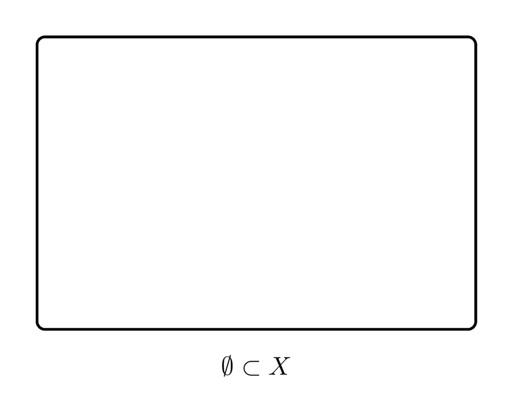

(a)

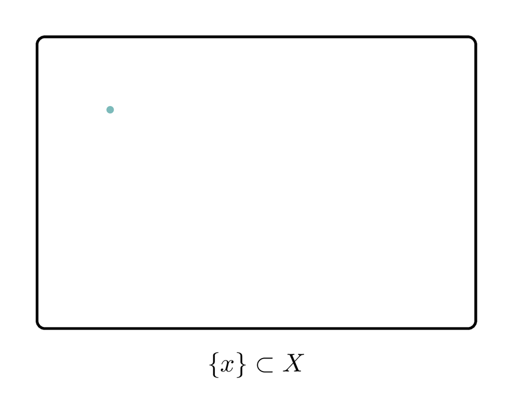

(b)

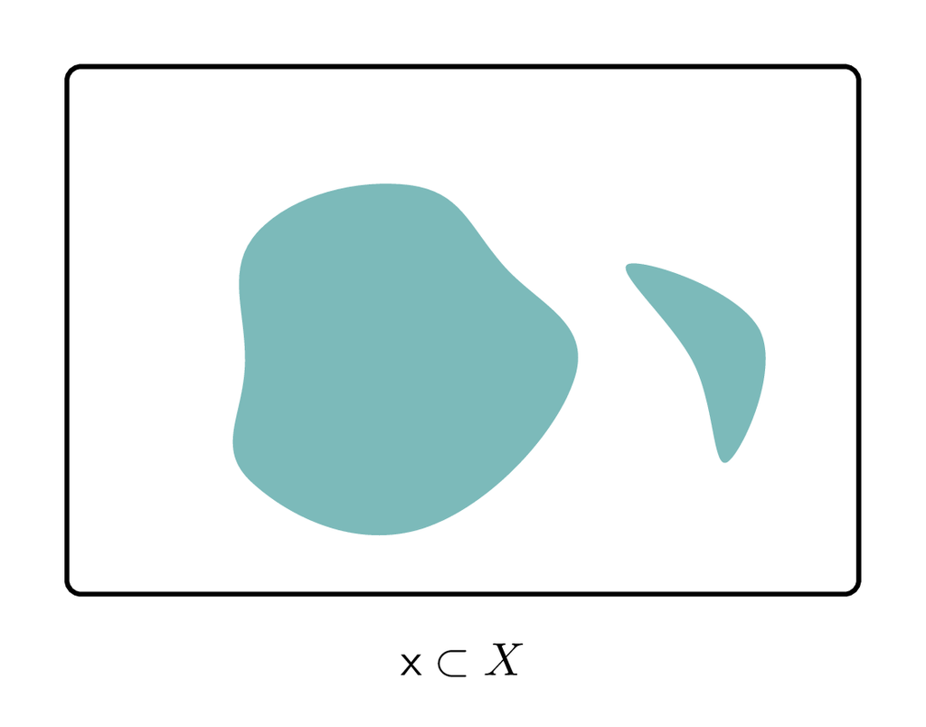

(c)

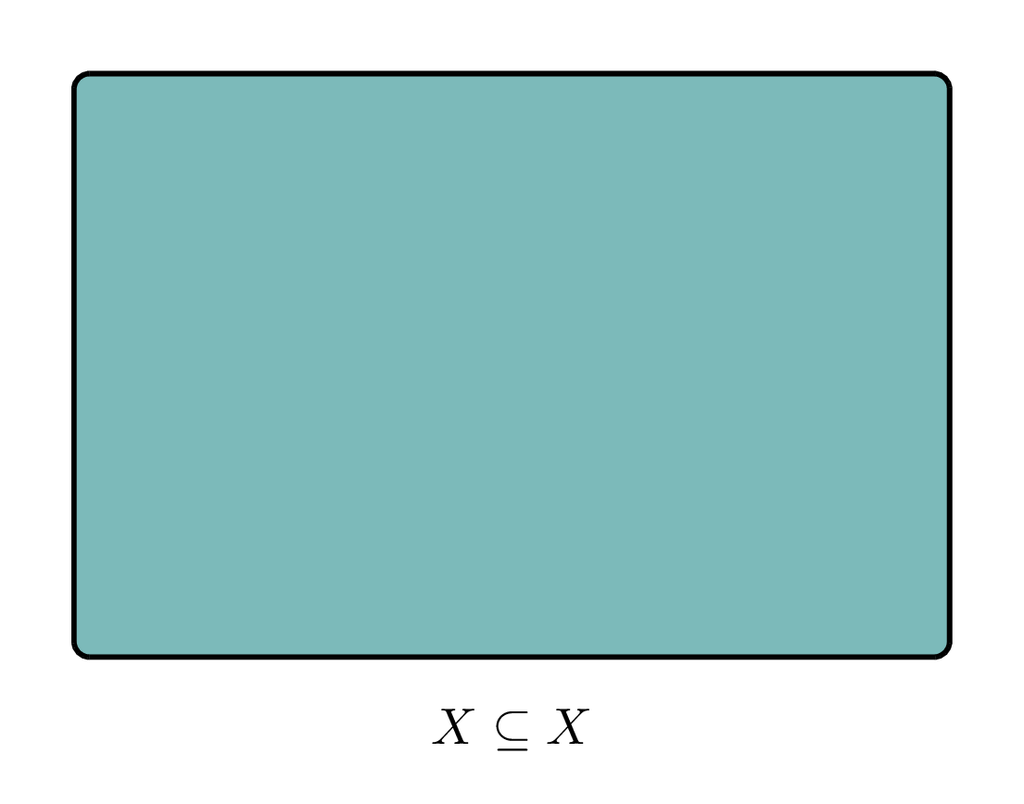

(d)

Figure 1: On a general set we can always construct (a) an empty set containing no elements, (b) atomic sets containing only a single element, and (d) a full set containing all elements in the set. (c) Most subsets are more intermediate, containing more than one but not all of the elements. Here filled shapes represent a potentially uncountable number of individual elements.

All of the set operations we introduced for finite sets generalize to any set. For example, for any set $X$ with power set $2^{X}$ we can define a unary operation that maps each subset into a **complementary** subset, or just **complement**, consisting of every other element (Figure 2),
$$\begin{alignat*}{6}
\cdot^c :\; & 2^X & &\rightarrow& \; & 2^X &
\\
& \mathsf{x} & &\mapsto& & \mathsf{x}^{c} &.
\end{alignat*}$$

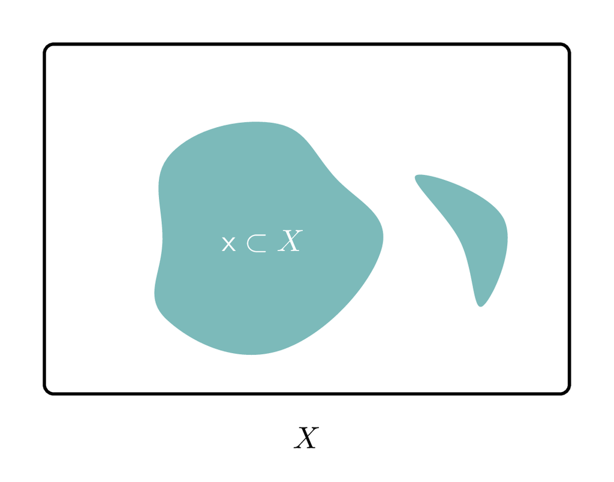

(a)

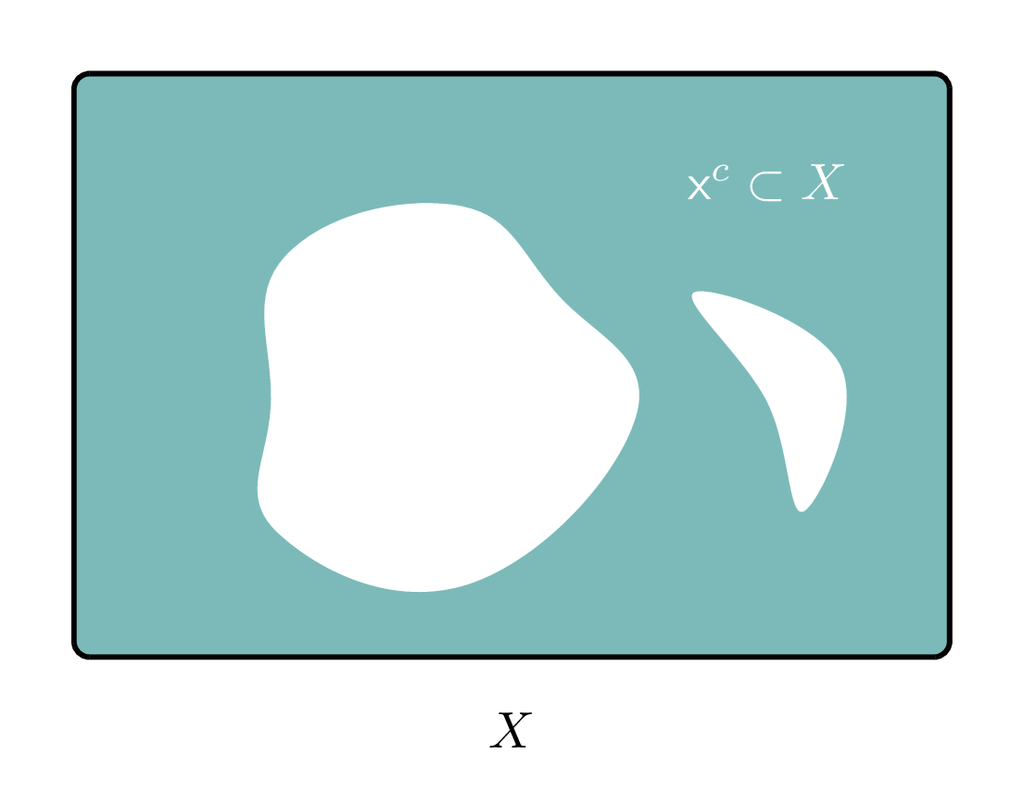

(b)

Figure 2: Every (a) subset defines a (b) complement subset consisting of all elements in the ambient set that are not contained in the initial subset.

For any set, the complement of the empty set is always the full set and vice versa,
$$\begin{align*}
\emptyset^{c} &= X
\\
X^{c} &= \emptyset.
\end{align*}$$

The binary union and intersection operations also generalize to any set (Figure 3). A **union** of two input subsets is the subset containing all of the elements contained in *either* input subset,
$$\begin{alignat*}{6}
\cdot \cup \cdot :\; & 2^{X} \times 2^{X}& &\rightarrow& \; & 2^{X} &
\\
& \mathsf{x}_1, \mathsf{x}_{2} & &\mapsto& & \mathsf{x}_1 \cup \mathsf{x}_2 &,
\end{alignat*}$$
and the **intersection** is the subset containing all of the elements in *both* input subsets,
$$\begin{alignat*}{6}
\cdot \cap \cdot :\; & 2^{X} \times 2^{X}& &\rightarrow& \; & 2^{X} &
\\
& \mathsf{x}_1, \mathsf{x}_{2} & &\mapsto& & \mathsf{x}_1 \cap \mathsf{x}_2 &,
\end{alignat*}$$
**Venn diagrams** visualize unions and intersections as overlapping shapes.

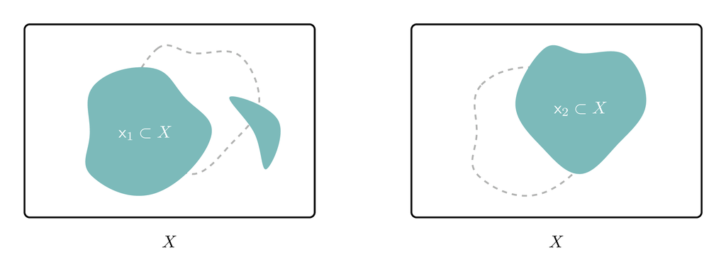

(a)

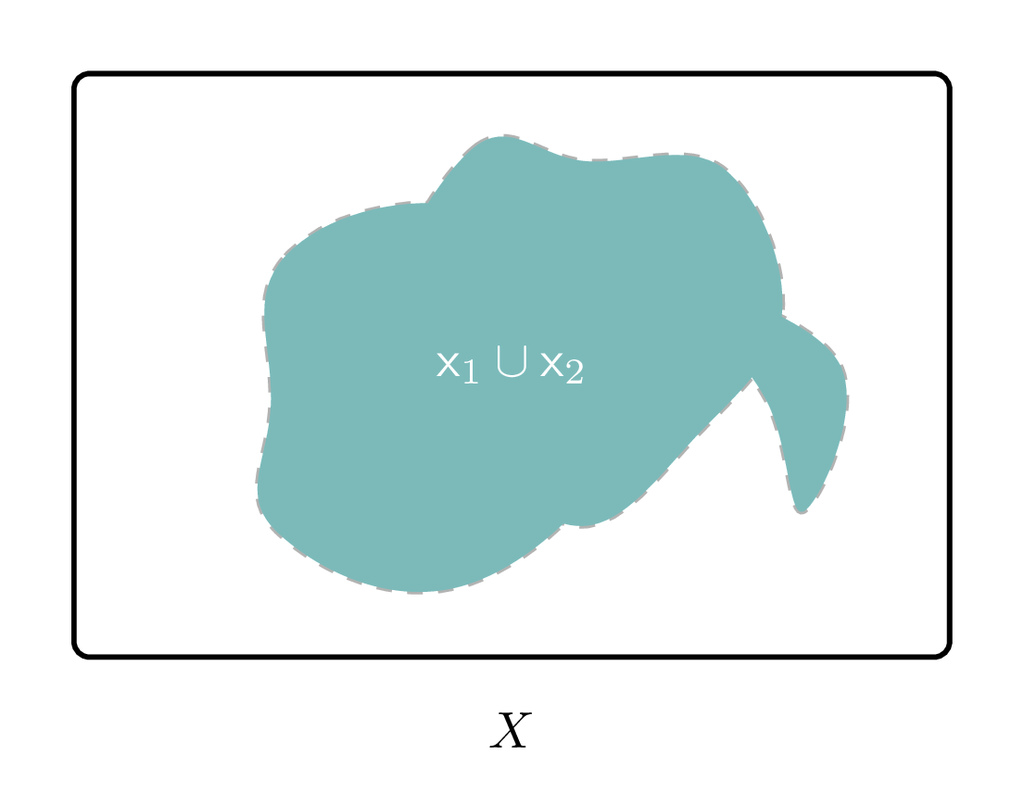

(b)

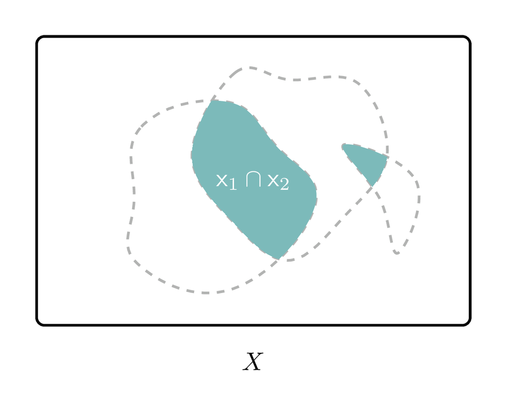

(c)

Two subsets are said to be **disjoint** when they don’t overlap, and hence don’t share any elements. More formally, two subsets are disjoint when their intersection is the empty set,
$$\mathsf{x}_{1} \cap \mathsf{x}_{2} = \emptyset.$$

All of the properties of these binary operations that we discussed for finite sets also generalize to arbitrary sets. For instance, the union and intersection of a subset with itself always returns that subset,
$$\mathsf{x} \cup \mathsf{x}
=
\mathsf{x} \cap \mathsf{x}
=
\mathsf{x}.$$
Similarly, the union of the empty set with any subset returns back that subset,
$$\mathsf{x} \cup \emptyset
=
\emptyset \cup \mathsf{x}
=
\mathsf{x},$$
and intersection of the empty set with any subset returns back the empty set,
$$\mathsf{x} \cap \emptyset
=
\emptyset \cap \mathsf{x}
=
\emptyset.$$
The union of any subset with the full set returns the full set,
$$\mathsf{x} \cup X = X \cup \mathsf{x} = X,$$
and the intersection of any subset with the full set returns back the subset,
$$\mathsf{x} \cap X = X \cap \mathsf{x} = \mathsf{x}.$$

The union and intersection operations also interact nicely with the complement operation. For example, the union of a subset and its complement is, by construction, the full set,
$$\mathsf{x} \cup \mathsf{x}^{c} = X.$$
On the other hand, the two subsets share no elements so their intersection is always empty,
$$\mathsf{x} \cap \mathsf{x}^{c} = \emptyset.$$
Consequently a subset and its complement are always disjoint.

## 1.2 Structures

A collection of elements alone is only so interesting mathematically, and only so useful in practice. The sets of theoretical and practical interest are equipped with additional **structures** that endow them with more rigidity and interpretability.

Earlier I defined a space as any set equipped with any structure. When that structure is explicit, we often denote the space by specifying the underlying set and the additional structure together. For instance, if we denote the set $X$ and the structure $\mathfrak{s}$ then we would denote the space that pairs them by $(X, \mathfrak{s})$. Unfortunately, these additional structures are often implicit and taken for granted. In particular, $X$ is often used to denote both the underlying set *and* the structure-informed space.

In this section we will review just a few of the structures that play important roles in practical applications. Specifically, we will focus on the structures that define the most common spaces that arise in mathematical modeling. We have already encountered *probabilistic* structures in [Chapter One](http://www.symplectomorphic.com/assets/chapters_html/probability_on_finite_sets.html), and we’ll explore them in full generality in [Chapter Four](http://www.symplectomorphic.com/assets/chapters_html/probability_on_general_spaces.html)

### 1.2.1 Ordering Structures

One way to enhance a set is to distinguish a special organization of its elements.

An **strict ordering**, **complete ordering**, or **total ordering** establishes a particular sequential arrangement of the elements in a set. Mathematically, we can encode an ordering as local relations between elements, writing $x_{1} < x_{2}$ if the element $x_{1}$ appears earlier in the ordering than $x_{2}$. In this case we also say that $x_{1}$ is *smaller* than $x_{2}$, and that $x_{2}$ is *larger* than $x_{1}$.

The ordering relation can also be interpreted as a binary operation that takes two distinct elements as inputs and returns $<$ if the first input element appears earlier in the ordering than the second input element and $>$ otherwise. This relation can also be relaxed to allow for the comparison of an element to itself with the introduction of a third equality output $=$ when the two input elements are equal.

A consistent ordering of the elements in a set strongly constrains the behavior of these relations. For example, if $x_{1} < x_{2}$ and $x_{2} < x_{3}$ then we must have $x_{1} < x_{3}$. This property is formally known as **transitivity** of the individual relations.

A **partial ordering** defines a less rigid arrangement of a set that doesn’t require every pair of elements to be comparable; in this case multiple elements can occupy the same position along the sequential arrangement at the same time. To represent a partial ordering we use the relation $\le$ and write $x_{1} \le x_{2}$ if the element appears earlier in the order *or at the same place in the order as* the distinct element $x_{2}$. As with a strict ordering relation, any partial ordering relation is transitive: if $x_{1} \le x_{2}$ and $x_{2} \le x_{3}$ then $x_{1} \le x_{3}$.

Intuitively, we can always interpret a strict ordering as a geometric arrangement of the elements along a one-dimensional line. Partial orderings are more general, but they can often be interpreted as a geometrical arrangement of the elements along a higher-dimensional plane. Critically, neither geometric interpretation relies on any notion of distance between the elements; any arrangement does not specify how far apart any two elements are.

A set equipped with a particular ordering is referred to as both an *ordered space* and an *ordinal space*. Likewise, a set equipped with a particular partial ordering is referred to as a *partially-ordered space*.

### 1.2.2 Algebraic Structures

The term **algebra** is introduced so early in our mathematical education that it can be especially easy to take for granted. It typically refers to equipping a set with one or more *binary operations* that manipulate any two input elements into a single output element. Some algebraic structures also introduce *unary operations* that transform a single input element into a single output element.

Just about every possible algebraic structure has been studied and categorized by mathematicians. Unfortunately, the resulting spaces are, with one exception, not usually referred to as “algebraic spaces”. In most cases they are not even referred to as “spaces”! Instead sets equipped with each algebraic structure are given special names, such as “magma” and “group” and “field”, that is not obviously related to the others.

Because of this barrage of terminology, it can be difficult to compare and contrast various algebraic structures. Fortunately, understanding them all is absolutely not necessary for this book. For those readers who are interested in digger a little bit deeper into the technical vocabulary, Wikipedia provides two nice reviews [here](https://en.wikipedia.org/wiki/Algebraic_structure#Common_algebraic_structures) and [here](https://en.wikipedia.org/wiki/Outline_of_algebraic_structures#Types_of_algebraic_structures).

In this section we will consider only a few particularly common algebraic structures.

#### 1.2.2.1 Single Algebraic Operation

A common convention when working with a single, binary algebraic operation is to denote that operation as
$$\begin{alignat*}{6}
\cdot :\; & X \times X& &\rightarrow& \; & X &
\\
& x_{1}, x_{2} & &\mapsto& & x_{1} \cdot x_{2} &,
\end{alignat*}$$
where $x_{1}$ denotes the first input element, $x_{2}$ denotes the second input element, and $x_{1} \cdot x_{2}$ denotes the output element. When working with multiple algebraic operations at the same time we will have to use multiple symbols to denote each operation.

Binary algebraic operations are characterized by a few key properties. For instance, a binary operation that is symmetric with respect to the input elements,
$$x_{1} \cdot x_{2} = x_{2} \cdot x_{1},$$
is referred to as a **commutative** operation.

A binary operation can be applied to more than two input elements by chaining multiple evaluations together. For example, we can apply a binary operation to the three elements $x_{1}$, $x_{2}$, and $x_{3}$ by first taking $x_{1}$ as $x_{2}$ inputs and then taking the resulting output as an input along with $x_{3}$,
$$(x_{1} \cdot x_{2}) \cdot x_{3}.$$
Alternatively, we can first take $x_{2}$ and $x_{3}$ as inputs and then take $x_{1}$ and the resulting output as inputs,
$$x_{1} \cdot (x_{2} \cdot x_{3}).$$
These two groupings will, in general, yield *different* outputs. Operations that always give the same output for both groupings are referred to as **associative** operations.

Some binary operations also distinguish special elements. For instance, inputting a particular element might reduce the operation to carrying forward the other input element to the output no matter what it might be. More formally, a binary operation might admit an element $x_{\text{Id}}$ such that
$$x \cdot x_{\text{Id}} = x_{\text{Id}} \cdot x = x$$
for all $x \in X$. If so then $x_{\text{Id}}$ is denoted a **unit element** or **identity element** and the binary operation itself is referred to as a **unital** operation.

Similarly, an operation might allow a particular element to determine the output no matter what the other input element is. Formally, there might exist an element $x_{\text{Null}}$ such that
$$x \cdot x_{\text{Null}}
=
x_{\text{Null}} \cdot x
=
x_{\text{Null}}$$
for all $x \in X$. If so then $x_{\text{Null}}$ is denoted an **absorbing element**, **null element**, or **zero element** with the binary operation sometimes referred to as a **null** operation.

The existence of an identity element can also induce a special pairing between the other elements in the set. Specifically, some elements $x \in X$ might be paired with another element $x^{-1} \in X$ such that the binary operation returns the distinguished identity element,
$$x \cdot x^{-1} = x^{-1} \cdot x = x_{\text{Id}}.$$
In this case we say that $x^{-1}$ is the **inverse element** of $x$. By construction, $x$ is also the inverse element of $x^{-1}$ and the identity element is always its own inverse element. Conversely, because inputing null elements to a binary operation cannot result in an identity element output, null elements can never have inverse elements.

Perhaps the most prominent binary algebraic operation is **addition** over the integers and real numbers. Addition is commutative, associative, and unital with the identity element $x_{\text{Id}} = 0$. Every element $x$ also features a unique additive inverse element known as its **negation** and written as $-x$. A corresponding **subtraction** operation can be defined as addition by additive inverses,
$$x_{1} - x_{2} \equiv x_{1} + (x_{2})^{-1} = x_{1} + (-x_{2}).$$

A natural complement to addition is **multiplication**. Multiplication is commutative, associative, and unital with the identity element $x_{\text{Id}} = 1$. It is also null with the absorbing element $x_{\text{Null}} = 0$.

When working with the integers, no element features a multiplicative inverse except for the identity element. On the other hand, every real number $x$ except for $x_{\text{Null}} = 0$ features a multiplicative inverse element known as its **reciprocal** that is written as $1 /x$. We can define a **division** operation as multiplication by multiplicative inverses,
$$x_{1} / x_{2} \equiv x_{1} \cdot (x_{2})^{-1}
=
x_{1} \cdot \frac{1}{x_{2}}.$$
Because $x_{\text{Null}} = 0$ doesn’t have a multiplicative inverse, however, we cannot divide by zero.

#### 1.2.2.2 Multiple Algebraic Operations

If one algebraic operation is good, then two should certainly be better. Multiple algebraic operations that are *compatible* with each other define particularly rich algebraic structures.

In the context of two binary algebraic operations, a common convention is to write the first operator as
$$\begin{alignat*}{6}
+ :\; & X \times X& &\rightarrow& \; & X &
\\
& x_{1}, x_{2} & &\mapsto& & x_{1} + x_{2} &
\end{alignat*}$$
and the second as
$$\begin{alignat*}{6}
\cdot :\; & X \times X& &\rightarrow& \; & X &
\\
& x_{1}, x_{2} & &\mapsto& & x_{1} \cdot x_{2} &
\end{alignat*}$$
in analogy with addition and multiplication. This notation might be used even if the operators do not actually correspond to the usual addition and multiplication operations.

The binary operation $\cdot$ is said to **distribute** across the binary operation $+$ if
$$x_3 \cdot (x_1 + x_2) = (x_3 \cdot x_1) + (x_3 \cdot x_2).$$
Note that this property is asymmetric – it does *not* imply that $+$ distributes across $\cdot$,
$$x_3 + (x_1 \cdot x_2) \ne (x_3 + x_1) \cdot (x_3 + x_2).$$
A common example of compatible algebraic operations is addition and multiplication over the integer and real numbers, where multiplication distributes across addition. An algebraic structure comprised of these two compatible operations is also sometimes known as an **arithmetic** operation.

One of the most infamous algebraic structures considers a slightly different combination of operations. Instead of a binary operator that takes two elements as inputs, we can define a binary operator that takes as inputs one element and one real number,
$$\begin{alignat*}{6}
\cdot :\; & \mathbb{R} \times X& &\rightarrow& \; & X &
\\
& \alpha, x & &\mapsto& & \alpha \cdot x &.
\end{alignat*}$$
This is sometimes referred to as a **scalar multiplication** operator.

A **linear algebra over the real numbers** complements this scalar multiplication operation with an associative, commutative, and unital binary operator
$$\begin{alignat*}{6}
+ :\; & X \times X& &\rightarrow& \; & X &
\\
& x_{1}, x_{2} & &\mapsto& & x_{1} + x_{2} &
\end{alignat*}$$
that interacts nicely with $\cdot$. For example, a linear algebra assumes that $\cdot$ distributes over $+$,
$$\alpha \cdot (x_{1} + x_{2}) = \alpha \cdot x_{1} + \alpha \cdot x_{2}.$$
A set equipped with these operators is also known as a **vector space** with the individual elements denoted **vectors**.

### 1.2.3 Metric Structures

Another way to add structure to a set is to introduce an explicit notion of **distance** between individual elements. Mathematically, this is done by introducing a binary operation that takes two elements as inputs and returns a positive real number as output,
$$\begin{alignat*}{6}
d :\; & X \times X& &\rightarrow& \; & [0, \infty] &
\\
& x_{1}, x_{2} & &\mapsto& & d(x_{1}, x_{2}) &.
\end{alignat*}$$

In order for this operation to conform with out intuitive notions of distance, we need it to satisfy a few key properties. For instance, the output should vanish when comparing an element to itself,
$$d(x_{1}, x_{2}) = 0$$
whenever $x_{1} = x_{2}$. At the same time, the output should be non-zero when comparing two distinct inputs,
$$d(x_{1}, x_{2}) > 0$$
whenever $x_{1} \ne x_{2}$. The operation should also be symmetric in its inputs,
$$d(x_{1}, x_{2}) = d(x_{2}, x_{1}),$$
and for any three elements satisfy a *triangle inequality*,
$$d(x_{1}, x_{3}) \le d(x_{1}, x_{2}) + d(x_{2}, x_{3}).$$
If the operation satisfies all of these properties then we can consistently say that the larger $d(x_{1}, x_{2})$ is, the most distant $x_{1}$ is from $x_{2}$.

Any operation satisfying these criteria is known as a **distance function** or **metric**. A set equipped with a metric is denoted a **metric space**.

Because a metric is symmetric in its inputs, it is insensitive to any ordering of the elements. In fact, the distances defined by a metric complement the arrangement defined by an ordering: an ordering defines how elements are arranged but not how far apart they are, while a metric defines how far apart the elements are but not their arrangement. Together an ordering and metric define a particularly rigid arrangement of the elements.

One of the most important applications of a metric is formalizing notions of *convergence* and *limits* in a set. Consider, for example, a countably infinite sequence of elements
$$\{ x_{1}, x_{2}, \ldots, x_{i}, \ldots \}.$$
A metric quantifies how far these elements are from any other element $x \in X$,
$$\{ r_{1}, r_{2}, \ldots, r_{i}, \ldots \}
=
\{ d(x_{1}, x), d(x_{2}, x), \ldots, d(x_{i}, x) \}.$$
Intuitively, if these distances decay towards zero then the sequence of elements will move closer and closer to $x$.

More formally, a sequence of elements **converges** to the **limit** $x$ if for *any* distance $\epsilon > 0$, no matter how small it might be, we can always go deep enough into the sequence that the distances between the tail elements
$$\{ x_{i'}, x_{i' + 1}, \ldots, x_{i' + i}, \ldots \}$$
and the limiting element $x$ are all bounded by $\epsilon$ (Figure 4),
$$\begin{align*}
d(x_{i'}, x) &< \epsilon
\\
d(x_{i' + 1}, x) &< \epsilon
\\
\ldots&
\\
d(x_{i' + i}, x) &< \epsilon
\\
\ldots&.
\end{align*}$$
In other words, the elements of a convergent sequence become arbitrarily close to $x$, at least eventually.

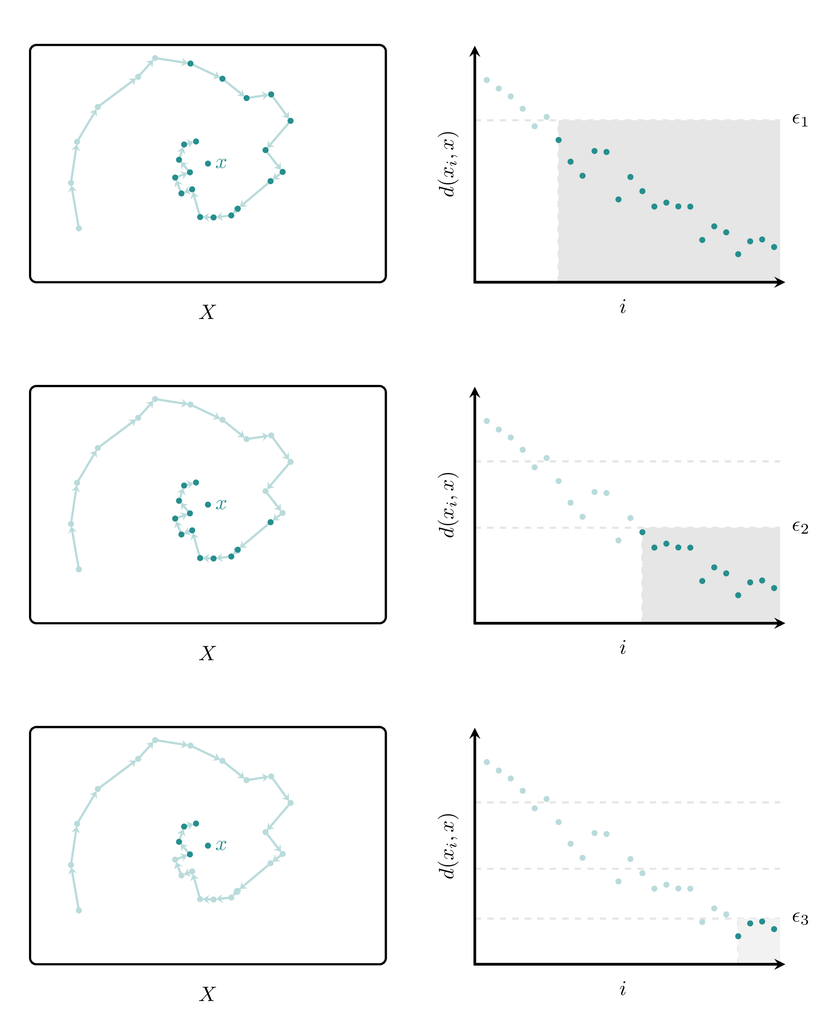

Figure 4: Equipping a set with a metric allows us to quantify when a sequence of elements converges to a limiting element $x \in X$. If the distance between the sequential elements and the limiting element $x$ is eventually bounded by any finite distance $\epsilon$, then the sequential elements will become arbitrarily close to $x$.

Convergent sequences can then be used to formally implement limits. In particular, the notation $x' \rightarrow x$ corresponds to *any* sequence of elements that converges to $x$. Limiting behavior is determined by how *all* of these convergent sequences behave.

### 1.2.4 Topological Structures

The distances defined by a metric endow a set with a rich diversity of useful features. Many of these features, however, can also be defined by instead distinguishing certain subsets.

#### 1.2.4.1 Open Balls

Open balls quantify which elements are in the *proximity* of the central element without directly referencing the metric. More formally, every open ball centered at $x \in X$ with finite but potentially arbitrarily small radius defines a **metric neighborhood** of $x$. The smaller a metric neighborhood is, the closer the elements it contains will be to the central element $x$. To emphasize the possibility of arbitrarily small metric neighborhoods I will use $\epsilon$ instead of $r$ when referring to the open ball radii that define metric neighborhoods.

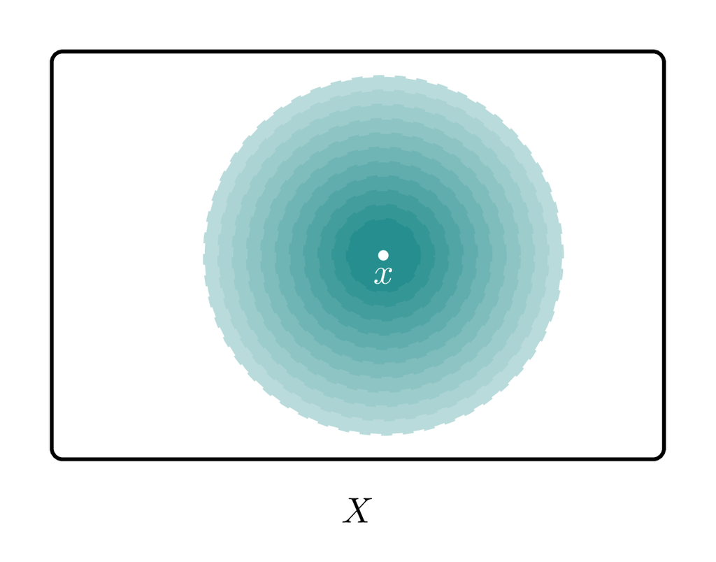

Figure 5: Open balls centered at $x \in X$ define neighborhoods of elements that are close to $x$. The smaller the neighborhood, the closer the elements are to $x$.

The interaction of these neighborhoods reveals quite a bit about the relationships between individual elements in a metric space. For example, because any pair of distinct elements are separated by a finite distance they can always be contained in non-overlapping metric neighborhoods (Figure 6). In other words, metric neighborhoods are able to *distinguish* individual elements from each other.

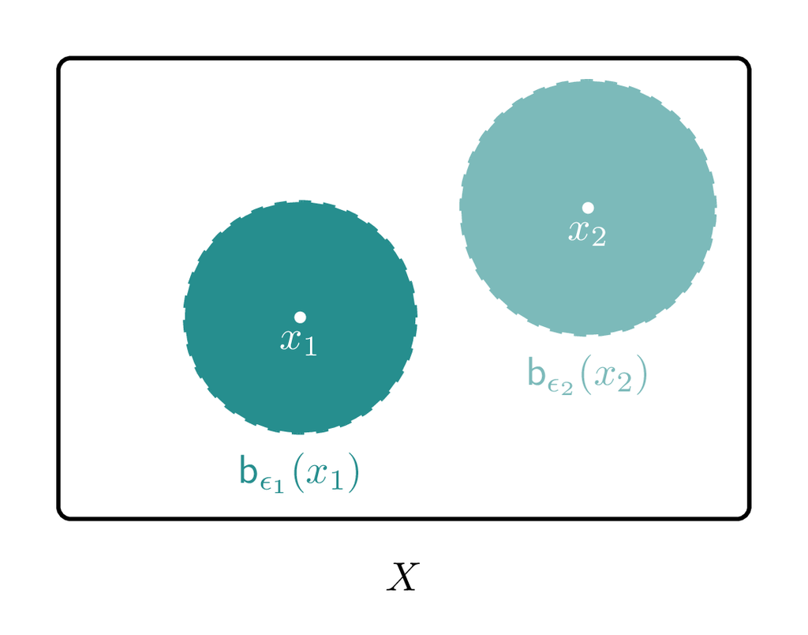

Figure 6: For any two elements $x_{1}, x_{2} \in X$ in a metric space, we can always find radii $\epsilon_{1} + \epsilon_{2} < d(x_{1}, x_{2})$ such that the open balls $\mathsf{b}_{\epsilon_{1}}(x_{1})$ and $\mathsf{b}_{\epsilon_{2}}(x_{2})$ containing the two elements will not overlap. Consequently metric neighborhoods are always able to separate individual elements.

Moreover, we can use metric neighborhoods to define convergent sequences. Recall that, by definition, we can always go deep enough into a convergent sequence so that the tail elements
$$\{ x_{i'}, x_{i' + 1}, \ldots, x_{i' + i}, \ldots \}$$
will be closer to the limiting element $x$ than any distance $\epsilon > 0$,
$$\begin{align*}
d(x_{i'}, x) &< \epsilon
\\
d(x_{i' + 1}, x) &< \epsilon
\\
\ldots&
\\
d(x_{i' + i}, x) &< \epsilon
\\
\ldots&,
\end{align*}$$
This, however, is equivalent to requiring that those tail elements are all contained in the open ball $\mathsf{b}_{\epsilon}(x)$ centered at the limiting element,
$$\{ x_{i'}, x_{i' + 1}, \ldots, x_{i' + i}, \ldots \}
\in \mathsf{b}_{\epsilon}(x).$$
In other words, a sequence will converge to the limit $x$ if and only if the elements in the sequence are eventually contained in *any* metric neighborhood of $x$ (Figure 7).

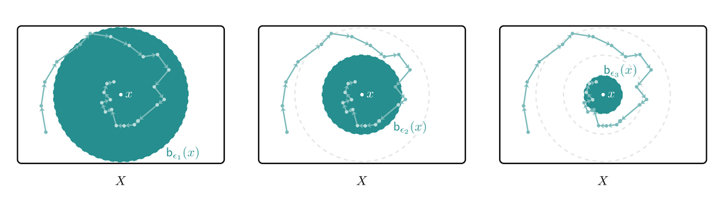

Figure 7: On a metric space, a sequence of elements converges to the limit $x \in X$ if and only if we can always go deep enough in the sequence that all subsequent elements are contained in any metric neighborhood.

Metric neighborhoods can also be used to formalize intuitive notions of “continuous” and “discrete” metric spaces. For instance, we can formalize the informal concept of a continuum by requiring that every element $x \in X$ is surrounded by elements at any arbitrary distance, at least up to some potentially maximum distance. More succinctly, for *every* element $x \in X$ and distance $0 < \epsilon \le \epsilon_{\max}$ we should be able to find another element $x' \in X$ satisfying
$$d(x, x') = \epsilon.$$
This requirement, however, is equivalent to every metric neighborhood with radius less than $\epsilon_{\max}$ defining a *distinct* subset of $X$, because increasing the radius will always introduce new elements. This then implies that every metric neighborhood of $x$, no matter how small, must contain more elements than just $x$. In other words, no metric neighborhood in a continuum can ever reduce to an atomic set.

On the other hand, the elements in a discrete metric space are not separated by arbitrary distances. They are instead separated by only certain distances, specifically distances bounded below by some *minimum* distance. In this case many metric neighborhoods are degenerate, reducing to the same subset of $X$ (Figure 8). Moreover, any metric neighborhood with radius smaller than the minimum distance will reduce to the atomic set containing only the central element. These smallest neighborhoods isolate the elements from each other.

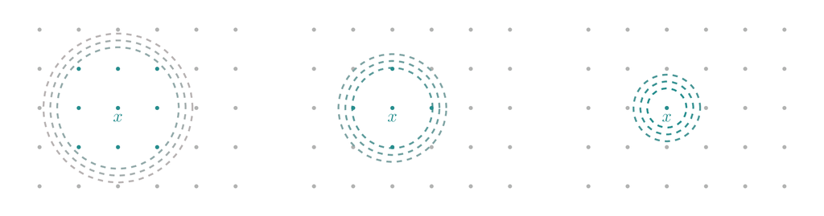

Figure 8: The elements in a discrete metric space are separated by some finite minimum distance, which is equivalent to many metric neighborhoods degenerating into the same subset. In particular, the smallest metric neighborhoods all degenerate to the atomic set which contains only the central element.

#### 1.2.4.2 Open Sets

The concept of open subsets can also be generalized beyond just open balls. Consider, for example, a subset $\mathsf{x} \subset X$ and an element $x \in \mathsf{x}$. If $x$ is contained in a metric neighborhood that is itself contained in the subset,
$$x \in \mathsf{b}_{\epsilon}(x) \subset \mathsf{x},$$
then we can move away from $x$ without ever leaving $\mathsf{x}$. When *every* element in $\mathsf{x}$ can be contained by at least one metric neighborhood that is also contained in $\mathsf{x}$, we can always move closer to the edge of the subset without leaving it.

A key consequence of this construction is that these subsets, just like the open balls, do not contain any boundary elements. Consequently they make a natural generalization for **open subsets** (Figure 9). We can then define **closed subsets** as the complements of open subsets. Closed subsets are characterized by their inclusion of elements whose metric neighborhoods all leak out into the surrounding set (Figure 10).

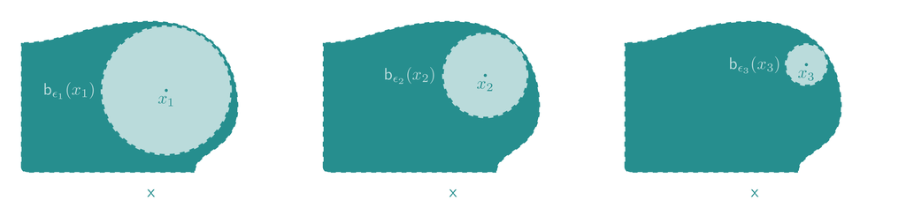

Figure 9: In a metric space, every element of an open subset can be contained by a metric neighborhood that is itself fully contained by the open subset. As we move closer and closer to the boundary of an open subset, the metric neighborhood will become smaller but never vanish. This allows us to make progressively smaller moves towards the boundary without ever actually reaching it.

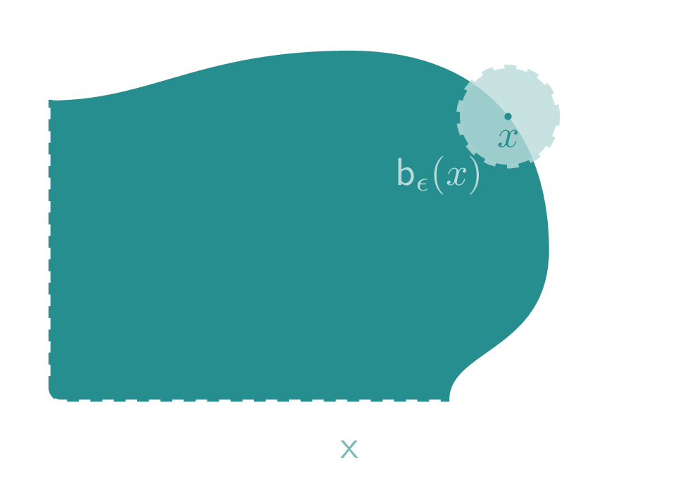

Figure 10: A closed subset of a metric space contains boundary elements whose metric neighborhoods all reach outside of the subset.

Unfortunately, this construction does introduce a few subtleties. Unlike the colloquial use of the words “open” and “closed”, these definitions of open subsets and closed subsets are not exact opposites. If a subset and its complement are both open then they will, by definition, be both open and closed at the same time. Because mathematicians have no shame, these subsets are referred to as “clopen” subsets. Moreover, open subsets and closed subsets are both exceptional in the power set; in general only *some* subsets will be open, closed, or both, and most subsets will be neither open nor closed.

Unlike open balls, these metric-derived open subsets are *closed* under unions and intersections. If $\mathsf{x}_{1}$ and $\mathsf{x}_{2}$ are both open subsets, then $\mathsf{x}_{1} \cup \mathsf{x}_{2}$ will also be an open subset. In fact, the union of *any* number of open subsets will always be open. Likewise, if $\mathsf{x}_{1}$ and $\mathsf{x}_{2}$ are both open subsets then $\mathsf{x}_{1} \cap \mathsf{x}_{2}$ will also be an open subset. Indeed, the intersection of any *finite* number of open subsets will also be open but, in an unfortunate asymmetry, the intersection of an infinite number of open subsets might not be open.

Open subsets provide an immediate way to generalize the notion of neighborhood beyond open balls. If we define a general neighborhood of $x$ to be *any* open subset that contains $x$, then we will be able to derive many of the same properties as metric neighborhoods, and hence the underlying metric. For example, two elements can be separated by metric neighborhoods if and only if they can be separated by open subsets more generally. Similarly, every sequence that converges to the limit $x$ is eventually contained not just by every metric neighborhood of $x$ by also by every general neighborhood of $x$.

While different metrics define different metric neighborhoods around each element, those different metric neighborhoods can sometimes end up defining the *same* open subsets (Figure 11). Because those open subsets completely characterize properties like separation and convergence, the metrics that yield the same open subsets will all share those properties! Working directly with a collection of open subsets allows us to avoid the idiosyncrasies of any particular metric and isolate the properties common to *all* compatible metrics.

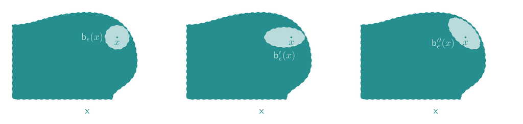

Figure 11: Different metrics define different metric neighborhoods, but in some cases those different metric neighborhoods end up defining the same collection of open subsets. Any property defined by those common open subsets will be shared by all of the compatible metrics.

#### 1.2.4.3 General Topologies

Once we can define interesting properties directly from open subsets, a natural question is whether or not those open subsets need to derived from any existing structure in the first place. Indeed, we can introduce all kinds of interesting properties to a set by equipping it directly with a self-contained collection of distinguished subsets.

A **topology** is any collection of subsets
$$\mathfrak{t}
=
\{
\emptyset, \mathsf{x}_{1}, \ldots, \mathsf{x}_{i}, \ldots, X
\} \in 2^{X}$$
that contains the empty set and the full set, is closed under arbitrary unions, and is closed under finite intersections. Any set equipped with a topology is referred to as a **topological space**.

The distinguished subsets that define a topology are generally referred to as **open subsets**, even if they are not derived from a metric. If the open subsets in a topology are derived from a particular metric, or *can be* derived from some metric, then we refer to the topology as a **metric topology**.

Non-empty subsets in a topology provide the ultimate generalization of neighborhoods. Every subset in a topology that contains the element $x \in X$ defines a neighborhood of $x$, with each neighborhood providing some quantification of which elements in the set are in the proximity of $x$ (Figure 12). Smaller neighborhoods imply a stronger sense of proximity than larger neighborhoods.

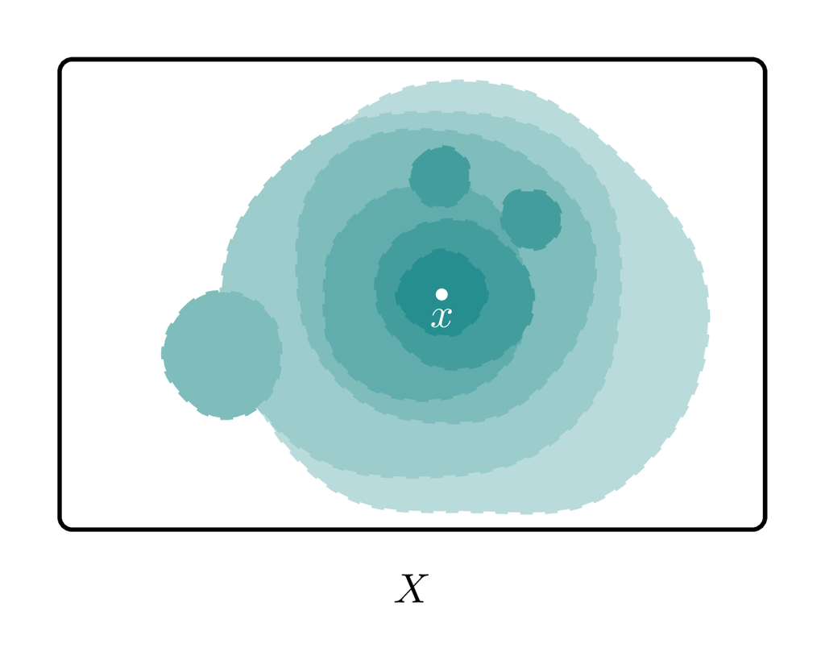

Figure 12: The subsets in a topology define a general notion of neighborhood. Any subset in the topology that contains an element $x \in X$ defines a neighborhood of elements in the proximity of $x$. Smaller subsets define smaller neighborhoods with stronger notions of proximity.

The overlap of topological neighborhoods around distinct elements determines how well the topology can distinguish those elements from each other. Larger topologies contain more neighborhoods that better resolve the individual elements in the underlying set than smaller topologies. In other words, the larger the topology is the closer we can zoom into the individual elements.

For instance, the smallest topology, known as the **trivial topology**, contains only the empty set and the full set,
$$\tau = \{ \emptyset, X \}.$$
In this case there is only one neighborhood, and that neighborhood is shared by *all* of the elements in $X$. Consequently, the topology is not able to discriminate any element from any other element.

At the other extreme, the **discrete topology** contains the entire power set,
$$\tau = 2^{X}.$$
Because the discrete topology contains every atomic set, each element can be contained in a neighborhood by itself, allowing us to zoom into each element individually and isolate it from every other element in $X$ (Figure 13). This generalizes the behavior of discrete metric spaces that we encountered in Section 1.2.4.1.

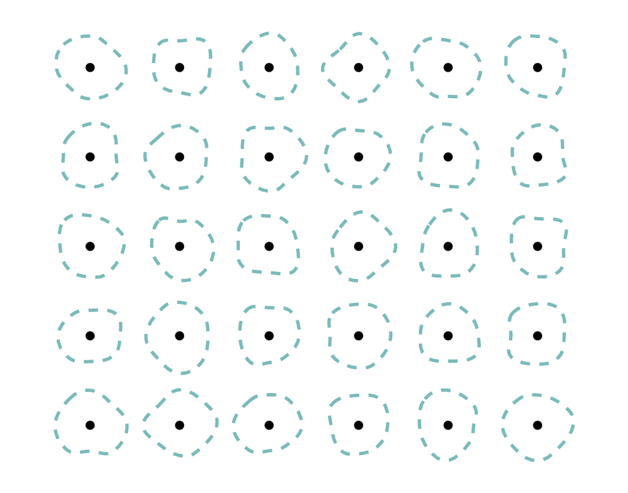

Figure 13: The discrete topology contains all of the atomic sets, each of which defines a neighborhood that completely isolates an element from every other element in the ambient set.

Particularly well-behaved topologies include enough subsets that every pair of elements can be contained by non-overlapping neighborhoods (Figure 14), mirroring the separation afforded by open subsets on metric spaces. These **Hausdorff topologies** are, in other words, able to distinguish every element from every other element.

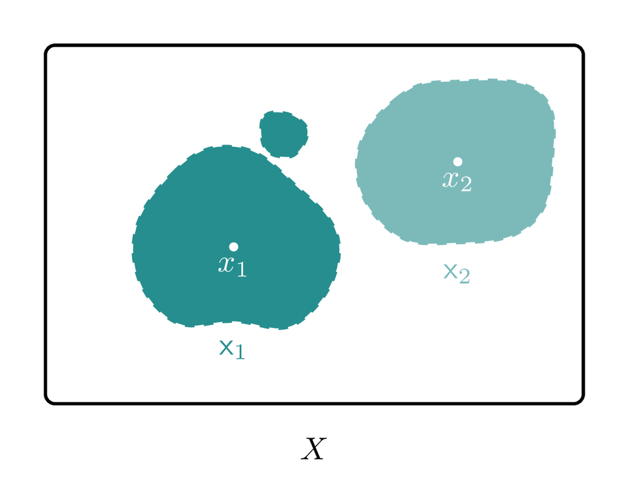

Figure 14: A Hausdorff topology includes enough subsets that every pair of elements $x_{1}, x_{2} \in X$ can be contained by at least one set of neighborhoods that don’t overlap with each other. More formally, $x_{1} \in \mathsf{x}_{1} \subset X$ and $x_{2} \in \mathsf{x}_{2} \subset X$ with $\mathsf{x}_{1} \cap \mathsf{x}_{2} = \emptyset$.

The continuous metric spaces discussed in Section 1.2.4.1 are generalized by topologies that fall in between the extreme trivial and discrete topologies. They contain enough subsets to be Hausdorff, but not so many to be discrete. This allows us to zoom in arbitrary close to each element, but never completely isolate them from neighboring elements. The precise subsets included in these intermediate topologies endow a set a certain notions of “shape”.

For example the half-open line interval
$$[0, 1) = \{ x \in \mathbb{R} \mid 0 \le x < 1 \}$$
is a Hausdorff topological space with open subsets defined by the open subintervals
$$(a, b) = \{ x \in \mathbb{R} \mid 0 < a < x < b < 1 \},$$
the half-open intervals that contain zero,
$$[0, b) = \{ x \in \mathbb{R} \mid 0 \le x < b < 1 \},$$
and their unions. The latter half-open subintervals contain elements near the lower boundary of zero, but *not* elements near the upper boundary of one. This separates the two ends of the interval from each other and gives the line its distinctive shape (Figure 15 (a)). Removing these subintervals gives *another* Hausdorff topology, but one where the obstructions between the elements near the lower boundary and the elements near the upper boundary have been removed. This effectively connects the two ends together, endowing the set not with the shape of a line but rather the shape of a circle (Figure 15 (b))!

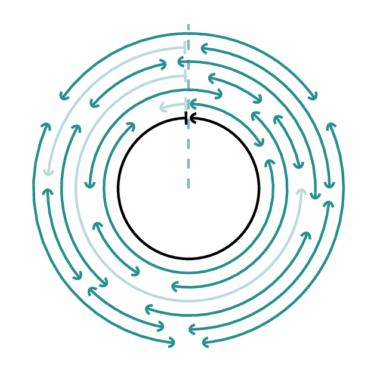

(a)

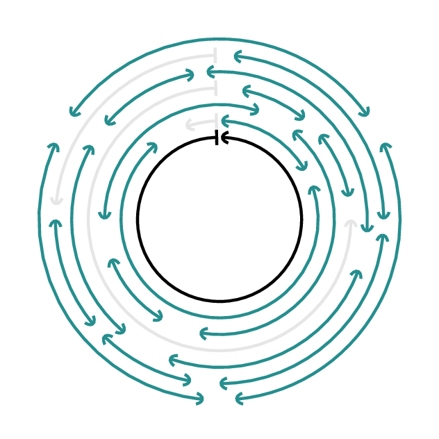

(b)

Convergence on topological spaces can be defined in the same way as it is on metric spaces, we just need to replace the neighborhoods derived from open balls to the neighborhoods defined by a topology (Figure 16). The generality of topological structure, however, does come at a cost: if a topology cannot separate individual elements then the limit of a convergent sequence might not be unique. Instead unique limits are guaranteed by only Hausdorff topologies.

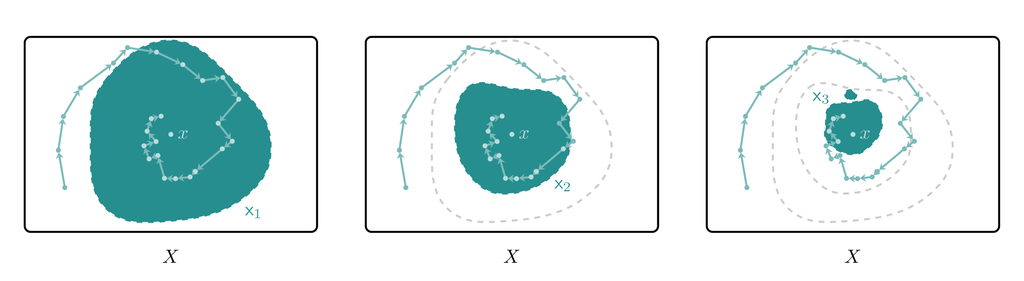

Figure 16: The subsets in a topology can be used to define convergent sequences in the same way that the open subsets in a metric space can: a sequence of elements converges to the limit $x \in X$ if and only if we can always go deep enough in the sequence that all subsequent elements are contained in any topological neighborhood of $x$. For many topologies, however, a sequence can converge to multiple elements at the same time. Unique limits are a feature of only some topologies.

A subtle benefit of this topological definition of convergence is that, because it doesn’t require a metric, it also doesn’t require us to define the real numbers that a metric outputs. This is helpful for avoiding circular logic when trying to formally define the real numbers in the first place!

#### 1.2.4.4 The Practical Uses of Topology

In general, topologies can be used to equip a set with all kinds of complicated structure, defining sophisticated spaces that far exceed our intuitions. Indeed, the construction and classification of elaborate topological spaces is a major focus of more abstract mathematics. Because most introductions to topology focus on these objectives, the subject has developed an imposing reputation of inaccessibility, if not outright irrelevance, to more applied aspirations.

Topology, however, can be a powerful tool in practice by helping us to better understand the familiar spaces that appear in more applied mathematics. Specifically, a given topology can be used to quantify which behaviors will be *shared* by different choices of other structures, such as orderings and metrics, and which behaviors are particular to those choices.

For example, if a topology is not Hausdorff then we won’t be able to distinguish between individual elements well enough to consistently define a metric that assigns non-zero distances $d(x_{1}, x_{2}) > 0$ to every pair of distinct elements $x_{1} \ne x_{2}$. In other words, *every* well-defined metric space must also be a Hausdorff topological space. Consequently, *every* metric space shares the properties that can be derived from Hausdorff topological structure alone, such as separation of elements by neighborhoods and uniqueness of convergent sequence limits.

Some metric spaces have even more topological similarities. In Section 1.2.4.2 we saw that different metrics on the same set can define the same open sets, and hence the same metric topology. Different metric spaces that induce the same metric topology are particularly alike, sharing every property that can be defined by that common topology. For instance, on metric spaces with the same topology convergent sequences will not only enjoy unique limits, they will share the *same* limits.

Similarly, all sets equipped with the topology of a line that we explored in Section 1.2.4.3 will share the same basic linear “shape” regardless of any compatible metric structure we introduce. At the same time, sets equipped with the topology of a circle will exhibit the same circular “shape”. Different metrics can warp how far apart the elements are from each other, but they cannot disrupt those topologically-derived shapes.

In other words, working with topological properties allows us to isolate all of the behaviors shared by spaces equipped with compatible structures and disregard the idiosyncrasies any particular choice of that structure. Consequently, topological structure is often interpreted as more *fundamental* than other structures. From this perspective, the foundation of a space is a set equipped with a particular topology. Any additional structure, such as an ordering, algebra, or metric just builds on top of that foundation.

## 1.3 Structure-Informed Subsets

Mathematically, it is much easier to work with structures that are *compatible* with each other. For example, if we want to equip a set with both a topology and a metric then the resulting space will be particularly well-behaved if we use a metric topology. At the same time, ambient structure can also distinguish certain compatible subsets.

For example, if a set is equipped with an ordering then we can define **interval** subsets that contain all elements above and below two boundary elements. An **open interval** excludes both boundary elements,
$$(x_{1}, x_{2}) =
\{ x \in X \mid x_{1} < x < x_{2} \}$$
while a **closed interval** includes them,
$$[x_{1}, x_{2}] =
\{ x \in X \mid x_{1} \le x \le x_{2} \}.$$
We can also define **half-open**, or equivalently **half-closed**, intervals that contain only one boundary,
$$\begin{align*}
(x_{1}, x_{2}] &= \{ x \in X \mid x_{1} < x \le x_{2} \}
\\
[x_{1}, x_{2}) &= \{ x \in X \mid x_{1} \le x < x_{2} \}.
\end{align*}$$
Note that these notions of “open” and “closed” subsets are, in general, distinct from the open and closed subsets defined by a topology. Only when an ordering is compatible with a topology will these open and closed intervals also be topologically open and closed.

As we saw in Section 1.2.4.1, a metric distinguishes subsets of elements surrounding a given element. This includes both open balls,
$$\mathsf{b}_{r}(x)
=
\{ x' \in X \mid d(x, x') < r \}$$
and closed balls,
$$\bar{\mathsf{b}}_{r}(x)
=
\{ x' \in X \mid d(x, x') \le r \} \in 2^{X}.$$
Open and closed balls will not necessarily be topologically open and closed unless the subset is endowed with a metric topology.

Finally, by construction any topology distinguishes open subsets and the complementary closed subsets. If an ordering, metric, and topology are all consistent with each other then we can associate these topological subsets with intervals and balls. In general, however, each structure can distinguish different subsets.

Because every topology contains the empty set and the full set, these subsets are always of interest. Moreover, when working with discrete topologies the atomic subsets that contain only a single element are particularly relevant.

# 2 Prototypical Spaces

The more structure that we endow onto a set, the richer its properties will be. That richness offers not only mathematical but also interpretational opportunities; indeed the spaces that are most common in practice are absolutely spoiled with structure. In section we’ll review the spaces that arise most often in mathematical modeling.

## 2.1 Power Set

The subsets of any set automatically feature a surprising amount of structure. We can then use that structure to elevate the power set into a space.

The union and intersection operations introduce algebraic structure, known as a **Boolean algebraic structure**, to the power set. They are both commutative,
$$\begin{align*}
\mathsf{x}_{1} \cup \mathsf{x}_{2}
&=
\mathsf{x}_{2} \cup \mathsf{x}_{1}
\\
\mathsf{x}_{1} \cap \mathsf{x}_{2}
&=
\mathsf{x}_{2} \cap \mathsf{x}_{1},
\end{align*}$$
and associative,
$$\begin{align*}
(\mathsf{x}_{1} \cup \mathsf{x}_{2}) \cup \mathsf{x}_{3}
&=
\mathsf{x}_{1} \cup (\mathsf{x}_{2} \cup \mathsf{x}_{3})
\\
(\mathsf{x}_{1} \cap \mathsf{x}_{2}) \cap \mathsf{x}_{3}
&=
\mathsf{x}_{1} \cap (\mathsf{x}_{2} \cap \mathsf{x}_{3}).
\end{align*}$$

Both operations are also unital, but with different identity elements. The identity element for the union operation is empty set,
$$\mathsf{x} \cup \emptyset
=
\emptyset \cup \mathsf{x}
=
\mathsf{x},$$
while the identity element for the intersection operation is the full set,
$$\mathsf{x} \cap X = X \cap \mathsf{x} = \mathsf{x}.$$
Interestingly, no elements but these identity elements admit inverse elements; no union can reduce a non-empty input subset to the empty set, and no intersection can elevate a non-full input subset to the full set.

These operations are also compatible with each other – not only do unions distribute across intersections,
$$\mathsf{x}_{3} \cup ( \mathsf{x}_{1} \cap \mathsf{x}_{2} )
=
(\mathsf{x}_{3} \cup \mathsf{x}_{1}) \cap
(\mathsf{x}_{3} \cup \mathsf{x}_{2}),$$
but also intersections distribute across unions,
$$\mathsf{x}_{3} \cap ( \mathsf{x}_{1} \cup \mathsf{x}_{2} )
=
(\mathsf{x}_{3} \cap \mathsf{x}_{1}) \cup
(\mathsf{x}_{3} \cap \mathsf{x}_{2}).$$

We can equip a power set with metrics and topologies, but the power set itself does not motivate any particular choice of these structures on its own. That said, metrics and topologies endowed on the underlying set can be used to derive compatible metrics and topologies on the power set.

## 2.2 Integers

The **integers**, denoted $\mathbb{Z}$, are the prototypical discrete space. This makes them particularly useful for modeling discrete quantities and indexing sequences of objects. Despite their ubiquity, however, we often take the structures that define the integers for granted.

Formally, the integers are built from a countably infinite set of elements equipped with a strict ordering, algebra, metric, and topology. The algebraic structure is given by the familiar arithmetic operations of addition and multiplication that are compatible with the ordering. We can define additive inverses, and hence subtraction, but we cannot define division because the multiplicative inverses don’t exist unless we expand the space to include fractions.

This algebraic structure can also be used to define a metric as
$$d(x_{1}, x_{2})
= \sqrt{ (x_{1} - x_{2}) \cdot (x_{1} - x_{2}) }
= | x_{1} - x_{2} |.$$
For this metric the distance between every sequential pair of integers is the same,
$$\begin{align*}
d(x_{n + 1}, x_{n})
&= | x_{n + 1} - x_{n} |
\\
&= | (x_{n} + 1) - x_{n} |
\\
&= | 1 |
\\
&= 1.
\end{align*}$$
Consequently the space is especially uniform.

Because this metric enforces a minimum distance between every pair of elements, it is compatible with the discrete topology. In particular, the atomic sets in the discrete topology maintain a strong separation between even neighboring elements.

This characterization of the integers is all well and good until we consider permuting the elements. Sorting the elements differently changes the ordering and algebraic operations, and the modified algebraic structure can define a different metric structure; elements that start next to each other can be permuted to be arbitrarily far apart. In general, only the discrete topology is invariant to permutations.

Despite all of this chaos, however, the behavior of the permuted space still conforms with our intuitions about the integers. In other words, we’ve reached a bit of an existential ambiguity. Every countably infinite set equipped with the discrete topology and *any* choice of compatible strict ordering, arithmetic operations, and metric defines a space which exhibits all of the features we expect of the integers!

This leaves us with two possible interpretations of the “integers”. On one hand, we can interpret the integers not as a single space but rather a *class* of spaces, with each choice of compatible non-topological structure defining a *distinct* instance. From this perspective, we can’t speak about *the* integers so much as *which* integers we use in any given application.

Alternatively, we can think of the integers as a single *flexible* space, with the different choices of non-topological structure defining different *configurations*. In this case it does make sense to talk about *the* integers, but at the same we have to specify a particular configuration to use the integers in any practical application.

Regardless of which interpretation we embrace, “the” integers admit a few particularly useful subspaces. We can construct the **natural numbers**,
$$\mathbb{N} = \{ x \in \mathbb{Z} \mid x \ge 0 \},$$
by removing the elements smaller than zero, and the **strictly positive natural numbers**
$$\mathbb{N}^{+} = \{ x \in \mathbb{Z} \mid x > 0 \}$$
by removing the zero element as well. More generally, we can construct subspaces from any interval of integers.

These subspaces inherit ordering, metric, and topological structure from the integers, but any the inherited algebraic structure will generally be modified. For instance, we can’t consistently define subtraction on the natural numbers because the difference between two positive integers can be negative, which falls outside of $\mathbb{N}$.

## 2.3 Real Lines

The prototypical model for a continuum, that appears to contain endless points no matter how closely we examine it, is the **real line**, $\mathbb{R}$. This space is also known as the **real numbers** and a **one-dimensional Euclidean space**. The real line sets the stage for important constructions like differential and integral calculus, but it also exhibits some subtle properties that can compromise our intuitions and require a bit of careful technical detail at times to avoid inconsistent behavior.

Formally, the real line is built from an uncountably infinite set of elements that, like the integers, is equipped with a strict ordering, algebra, metric, and topology. The algebraic structure includes addition and multiplication operators which can also be be used to define corresponding subtraction and division operators.

At the same time, the binary multiplication operator also satisfies the criteria for a scalar multiplication operator, making the real line a vector space as well. From a linear algebraic perspective, we can interpret a real line not as a collection of points but rather a collection of arrows stretching from the zero to each point.

As with the integers, the algebraic structure on the real line can be used to construct a metric,
$$d(x_{1}, x_{2}) = \sqrt{ (x_{1} - x_{2}) \cdot (x_{1} - x_{2}) },$$
which then defines a compatible metric topology.

Unfortunately, this construction is not unique and the real line suffers from the same interpretational ambiguity as the integers. Every uncountably infinite set equipped with a certain non-discrete, Hausdorff topology and *any* choice of compatible ordering, algebra, and metric defines a space that behaves like a real line. Consequently, we have to accept that $\mathbb{R}$ does not completely specify a space.

On one hand, we can take $\mathbb{R}$ to denote a class of real lines, with infinitely many distinct realizations defined by different choices of ordering, algebra, and metric. I will refer to this as the **rigid real line** interpretation.

On the other hand, we can interpret $\mathbb{R}$ as a single, flexible space that can be configured in an infinite number of different ways by choosing different auxiliary structures. I will refer to this as the **flexible real line** interpretation. In this latter perspective, the different configurations are also known as different **parameterizations** of the real line.

The power set of a real line contains a wealth of subsets that we can use to construct useful subspaces. For example, the integers are a subset of the real line, $\mathbb{Z} \subset \mathbb{R}$. We can also define the **positive real line** as
$$\mathbb{R}^{+} = \{ x \in \mathbb{R} \mid x \ge 0 \}.$$
More generally, any interval of a real line defines a subspace. All of these subspaces inherit topological, ordering, and metric structure from the initial real line, but they may not inherit all of the algebraic structure.

Regardless of the interpretation, we can use the metric structure of a real line to construct a useful visualization of the space. In particular any partition of the real line into equally long intervals,
$$\ldots, x_{-i}, \ldots, x_{-1}, x_{0}, x_{1}, \ldots, x_{i}, \ldots$$
with
$$d(x_{i + 1}, x_{i}) = \delta,$$
defines a **grid** that can be used to communicate its basic structure (Figure 17).

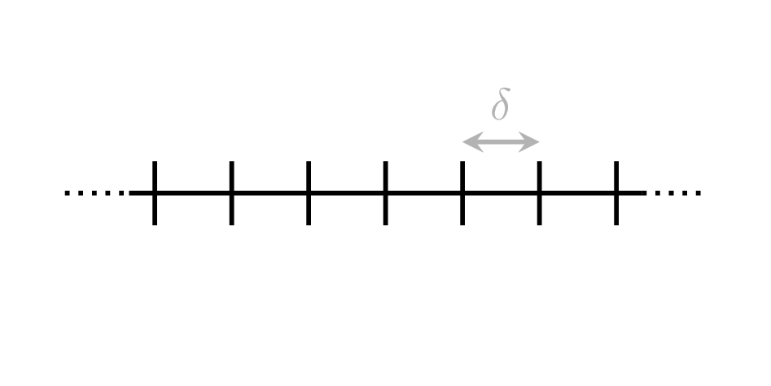

Figure 17: A grid of equally distant elements in a real line partitions the space into equally long intervals that communicates the metric structure.

## 2.4 Extended Real Lines

One limitation of a real line is that it contains points that are arbitrarily close to negative or positive infinity, but not those infinities themselves. An **extended real line** introduces two new elements: one smaller than all elements in the initial real line to represent negative infinity, and one larger than all of the elements to represent positive infinity. In other words, we can interpret an extended real line as the closed interval $[-\infty, \infty]$ while a real line is the corresponding open interval $(-\infty, \infty)$.

The inclusion of these two points does introduce some slight technical challenges. For instance, the algebraic structure is complicated by the fact that neither $-\infty$ nor $+\infty$ have well-defined additive or multiplicative inverses, unlike most other points. To avoid any inconsistencies we have to slightly tweak any structure derived from these operations, such as the metric and the corresponding metric topology.

Appending positive infinite to a positive real line defines an **extended positive real line** $[0, +\infty]$. We have already been sneakily introduced to the extended positive real line in [Chapter One](http://www.symplectomorphic.com/assets/chapters_html/probability_on_finite_spaces.html), where we used it to model the potentially infinite reservoir that we want to allocate across a finite set. In [Chapter Four](http://www.symplectomorphic.com/assets/chapters_html/probability_on_general_spaces.html) we will use it model a potentially infinite reservoir to be allocated across any set.

# 3 Relating Spaces

One we have defined spaces, a natural question is how we can relate different spaces to each other. This requires relating not only the elements in different sets but also any structures that we have endowed onto those sets.

## 3.1 Relating Sets

A **function**, also known as a **map** or **transformation**, is a relation between the elements of some *input* set and the elements of some *output* set (Figure 18). We denote functions as $f : X \rightarrow Y$, where $X$ denotes the input set and $Y$ denotes the output set. If we want to be more detailed, then we can also write
$$\begin{alignat*}{6}
f :\; & X & &\rightarrow& \; & Y &
\\
& x & &\mapsto& & y = f(x) &,
\end{alignat*}$$
where $x \in X$ is a variable taking values in the input set and $y \in Y$ is a variable taking values in the output set. This allows us to, for example, detail how exactly the function transforms $x$ into $y$.

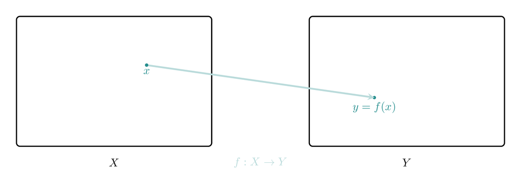

Figure 18: A function relates elements of an input set $X$ to elements of an output set $Y$.

One potential source of confusion when working with functions is mistaking a function $f : X \rightarrow Y$ with the *evaluation* of a function on a given input variable, $y = f(x) \in Y$.

### 3.1.1 Classifying Functions

There are many ways to relate the elements from a given input set to the elements of given output set. Some relations, however, are more useful than others. In order to understand the potential utility of different functions, it helps to categorize them based on some basic properties.

For example, if each input element maps to one, and only one, output element then equal function outputs will always imply equal function inputs and vice versa. More formally, when $f(x_1) = f(x_2)$ if and only if $x_1 = x_2$ we say that the function $f$ is **injective** (Figure 19). Non-injective functions are also known as **many-to-one** functions.

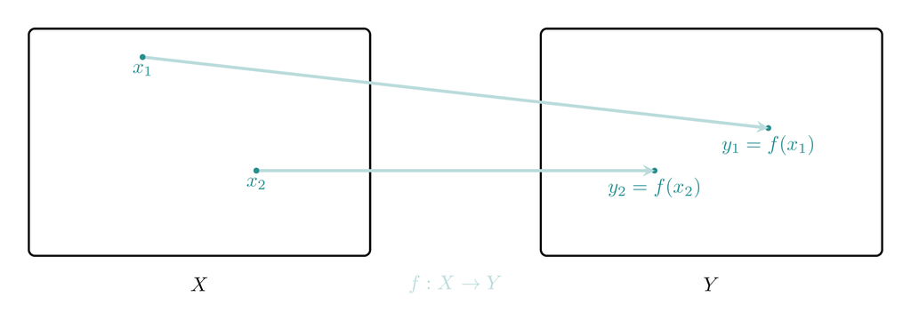

(a)

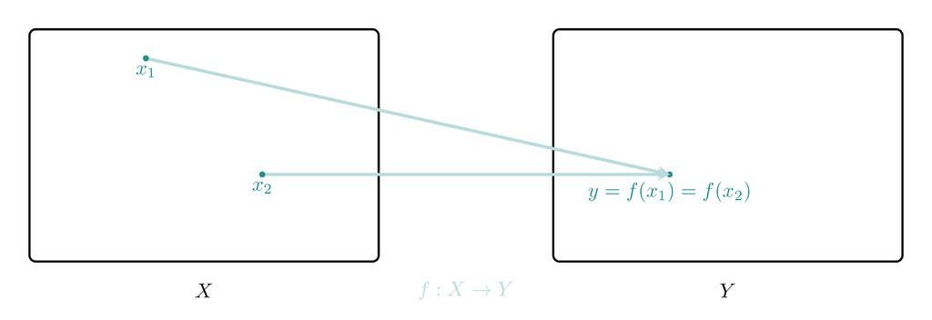

(b)

Figure 19: An (a) injective function maps each distinct input element to a distinct output element. A (b) non-injective function maps two or more input elements to the same output element.

Similarly, if each element of $Y$ is the output of evaluating $f$ on some input element in $X$ then the function is said to be **surjective** (Figure 20).

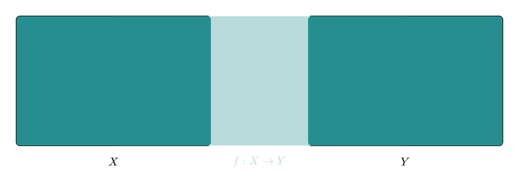

(a)

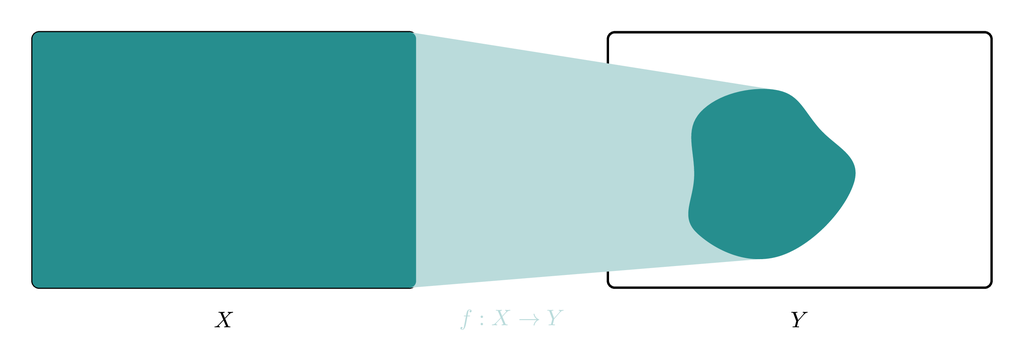

(b)

Figure 20: A (a) surjective function maps input elements to *every* element in the output set. A (b) non-surjective function maps input elements to only a subset of the output set.

When a function is both injective and surjective, *every* output element is uniquely paired with a single input element. In other words, the input set and the output set are in perfect correspondence. These functions are known as **bijective** functions.